# clockplot

The package `clockplot` is used to generate clock charts showing event times on a 24-hour clock. Additionally it helps you make a day chart, week chart, or month chart, or plan events in those periods.

The main focus is on the `clock_chart*()` functions. These allow you to plot event times on a 24-hour clock.

## Getting started

After installing the package, load it to use the available functions.

```r
library(clockplot)
```

## Types of Charts

The clockpolot offers three types of plot

1. Clock charts
2. Cyclic charts
3. Period planner

The first type shows event times on a 24 hour clock. The times can be arbitrary in the formats `HH:MM:SS`, `HH:MM` or even `H:M` (such as `9:3`), and not necessarily specific hours at all.

The second type allows you to show values during a certain duration (day, week, month, and year). There is a generic function `cyclic_chart()` for arbitrary period, while there charts specially made for specific period (day, week, year etc.)

Finally, the third one can help you make a plan in a certain period (day, week, month, and year), presenting tasks against period.

## Clock Charts

Below is a summary of each `clock_chart*()` function use case.

| **function** | **Purpose** |
| --- | --- |
| `clock_chart()` | To plot a basic clock chart, showing event times on clock, and to optionally choose a color for the hands |
| `clock_chart_col()` | To color the plot by a quantitative variable, and optionally to change size of points by the same or another variable |
| `clock_chart_qnt()` | To modify the length of the hands by a quantitative variable, along with all the options of `clock_chart_col()` |
| `clock_chart_qlt` | To use a qualitative variable as the criteria |

Now Let’s see each in greater detail

The examples use built-in data sets. The allowed time formats for these family of charts are `HH:MM:SS`, `HH:MM` or even `H:M` (such as `12;30:09` or `9:3`).

### Basic Clock Chart

This is the simplest clock chart; the hands are neither colored nor length modified by a criteria.

We are going to use the `smsclock` data set. Let us take a look on it.

```r
head(smsclock)
```

```
#> # A tibble: 6 × 7
#>   Date       day       time     sender invoked type  Title
#>   <chr>      <chr>     <chr>    <chr>  <chr>   <chr> <chr>
#> 1 01-09-2024 Sunday    14:29:00 Airtel No      offer AirtelTune
#> 2 01-09-2024 Sunday    20:28:00 Airtel No      offer AirtelTune
#> 3 02-09-2024 Monday    10:43:00 Airtel No      offer AirtelTune
#> 4 03-09-2024 Tuesday   13:15:00 Airtel No      offer AirtelTune
#> 5 04-09-2024 Wednesday 12:24:00 Airtel No      offer AirtelTune
#> 6 04-09-2024 Wednesday 17:45:00 Airtel No      offer AirtelTune
```

The necessary code to produce a chart is simply the following:

```r
clock_chart(smsclock, time, Col = "green")
```

The code produces a `ggplot2` object, so we can add (`+`) extra components to make it more informative.

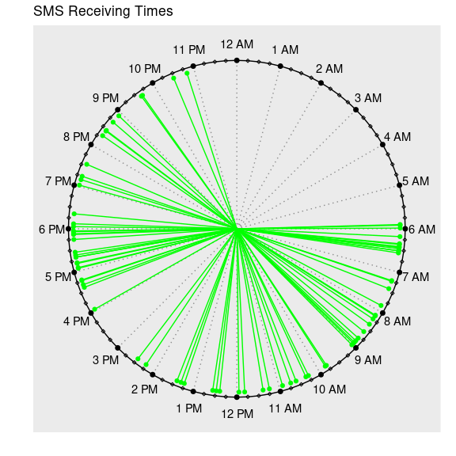

```r
p1 <- clock_chart(smsclock, time, Col = "green")
p1 + ggplot2::labs(title = "SMS Receiving Times")
```

### Colored Clock Chart

In the previous chart, we colored the hands by an arbitrary color. We may want to color it by a `numeric` variable. `clock_chart_col()` exactly does this.

We may use `bdquake` data set for this.

```r
head(bdquake)
```

```
#>   latitude longitude  depth mag      hms
#> 1  24.3726   92.6936 35.000 4.4 21:12:27
#> 2  25.7318   91.0047 41.021 4.1 02:20:09
#> 3  21.9812   92.6510 44.892 4.1 16:46:37
#> 4  25.7414   90.2866 10.000 4.4 08:57:52
#> 5  25.2901   91.7860 46.386 4.2 03:16:57
#> 6  23.1475   90.9317 45.057 5.5 03:35:33
```

The code without added components.

```r
clock_chart_col(bdquake, time = hms, crit = mag)
```

Let us modify it.

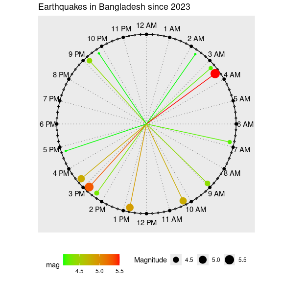

```r
p <- clock_chart_col(bdquake, time = hms, crit = mag)
p + ggplot2::labs(size = "Magnitude", title = "Earthquakes in Bangladesh since 2023")
```

It would be great if we could modify the length of the hands as well. We see that in the next chart.

### Chart with Modified and Colored Hands

```r
clock_chart_qnt(
  data = bdquake, time = hms, len = depth,
  Col = mag, high = "red", low = "blue"
)
```

The `high` and `low` color names can be vice versa or other colors, depending on the context. To use a single color for all lines, use same value for `high` and `low`

**The custom plot**

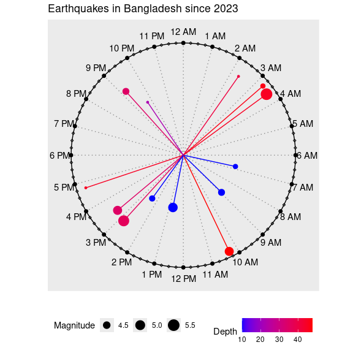

```r
p1 <- clock_chart_qnt(
  data = bdquake, time = hms, len = depth,
  Col = mag, high = "red", low = "blue"
)
p1 + ggplot2::labs(
  color = "Depth", size = "Magnitude",
  title = "Earthquakes in Bangladesh since 2023"
)
```

If you do not have two variables for `len` and `Col`, use one single variable for both options.

As is evident from the chart, the size of the points represents the magnitude of the earthquakes, while the color and the length of the hands stand for depth of the earthquakes.

If we want a single variable to determine color and length, we can use the following method to properly show the legend. The plot code is shown as a comment. To see the result, uncomment and run.

```r
labs(size = "TITLE", color = "")
# clock_chart_qnt(acdt, time = Time, len = Temperature.F., Col = Temperature.F.)+labs(size = "Temperature", color = "")
```

#### US Accidents plot

The data is taken from [Kaggle](https://www.kaggle.com/datasets/sobhanmoosavi/us-accidents) and a small part (100 rows) extracted. To see the modified data, visit [this link](https://raw.githubusercontent.com/mahmudstat/open-analysis/main/data/usacc.csv).

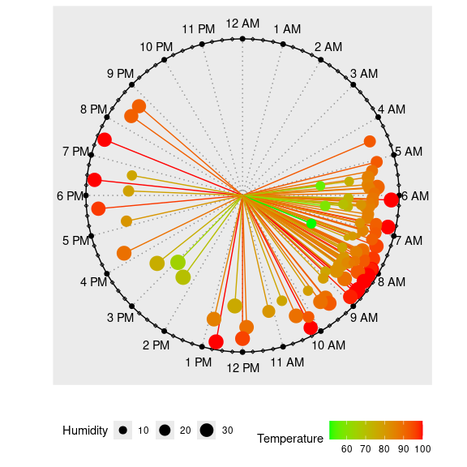

```r
acdt <- read.csv("https://raw.githubusercontent.com/mahmudstat/open-analysis/main/data/usacc.csv")
clock_chart_qnt(acdt, time = Time, len = Humidity..., Col = Temperature.F.) +
  ggplot2::labs(size = "Humidity", color = "Temperature")
```

### Qualitative variable

Here we use the built-in `smsclock` data set.

```r
head(smsclock, 4)
```

```
#> # A tibble: 4 × 7
#>   Date       day     time     sender invoked type  Title
#>   <chr>      <chr>   <chr>    <chr>  <chr>   <chr> <chr>
#> 1 01-09-2024 Sunday  14:29:00 Airtel No      offer AirtelTune
#> 2 01-09-2024 Sunday  20:28:00 Airtel No      offer AirtelTune
#> 3 02-09-2024 Monday  10:43:00 Airtel No      offer AirtelTune
#> 4 03-09-2024 Tuesday 13:15:00 Airtel No      offer AirtelTune
```

Now let us plot times with respect to message title.

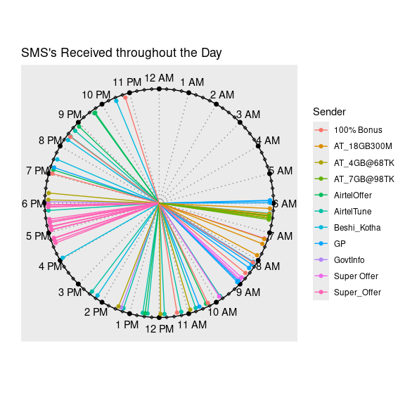

```r
clock_chart_qlt(smsclock, time = time, crit = Title) +
  ggplot2::labs(color = "Sender", title = "SMS's Received throughout the Day")
```

We can also make use of the `facet_wrap()` function from the `ggplot2` package.

We can use the following to see the visual relationship between message Sender and the Day of the week.

```r
clock_chart_qlt(smsclock, time = time, crit = sender) + facet_wrap(~day)
```

Or we may be interested to see the association between message title and the time when they are sent.

```r
clock_chart_qlt(smsclock, time = time, crit = sender) + facet_wrap(~Title)
```

## Other Charts

#### Cyclic Chart

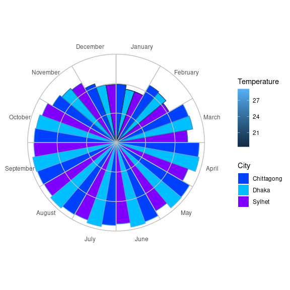

```r
Col <- c("#0040ff", "#00bfff", "#8000ff")
cyclic_chart(bdtemp,
  Period = Month, Value = Temperature,
  crit = City, ColV = Col
)
```

Or we can also make day or week charts.

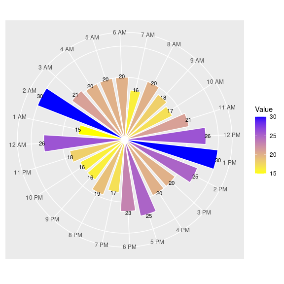

```r
value <- sample(15:30, 24, replace = TRUE)
day_chart(hvalue = value, high = "blue", low = "yellow", width = 0.8)
```

To see all the available functions, run `getNamespaceExports("clockplot")` and then use `?function_name` to know more about it and see and run examples. If you are connected to the internet, [you may visit](https://github.com/mahmudstat/clockplot) the repository and follow the website linked to see all the available functions (`Reference` menu)